# StarHotelSolution

### Cost Complexity Pruning

```python
clf = DecisionTreeClassifier(random_state=1, class_weight={0: 0.62, 1: 0.38})
path = clf.cost_complexity_pruning_path(X_train, y_train)
ccp_alphas, impurities = abs(path.ccp_alphas), path.impurities
```

```python
pd.DataFrame(path)
```

|  | ccp_alphas | impurities |
| --- | --- | --- |
| 0 | 0.000000e+00 | 0.007431 |
| 1 | -1.355253e-19 | 0.007431 |
| 2 | 8.990695e-21 | 0.007431 |
| 3 | 8.990695e-21 | 0.007431 |
| 4 | 8.990695e-21 | 0.007431 |
| ... | ... | ... |
| 3245 | 7.220354e-03 | 0.334179 |
| 3246 | 1.136220e-02 | 0.345541 |
| 3247 | 1.173487e-02 | 0.357276 |
| 3248 | 2.618965e-02 | 0.409655 |
| 3249 | 9.034402e-02 | 0.499999 |

3250 rows × 2 columns

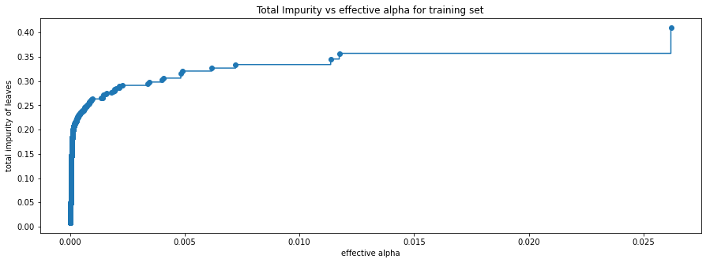

```python
fig, ax = plt.subplots(figsize=(15, 5))
ax.plot(ccp_alphas[:-1], impurities[:-1], marker="o", drawstyle="steps-post")
ax.set_xlabel("effective alpha")
ax.set_ylabel("total impurity of leaves")
ax.set_title("Total Impurity vs effective alpha for training set")
plt.show()
```

- Next, we train a decision tree using the effective alphas. The last value in ccp_alphas is the alpha value that prunes the whole tree, leaving the tree, clfs[-1], with one node.

```python
clfs = []
for ccp_alpha in ccp_alphas:
    clf = DecisionTreeClassifier(
        random_state=1, ccp_alpha=ccp_alpha, class_weight={0: 0.62, 1: 0.38}
    )
    clf.fit(X_train, y_train)
    clfs.append(clf)
print(
    "Number of nodes in the last tree is: {} with ccp_alpha: {}".format(
        clfs[-1].tree_.node_count, ccp_alphas[-1]
    )
)
```

```
Number of nodes in the last tree is: 1 with ccp_alpha: 0.09034402450808499
```

- For the remainder, we remove the last element in clfs and ccp_alphas, because it is the trivial tree with only one node. Here we show that the number of nodes and tree depth decreases as alpha increases.

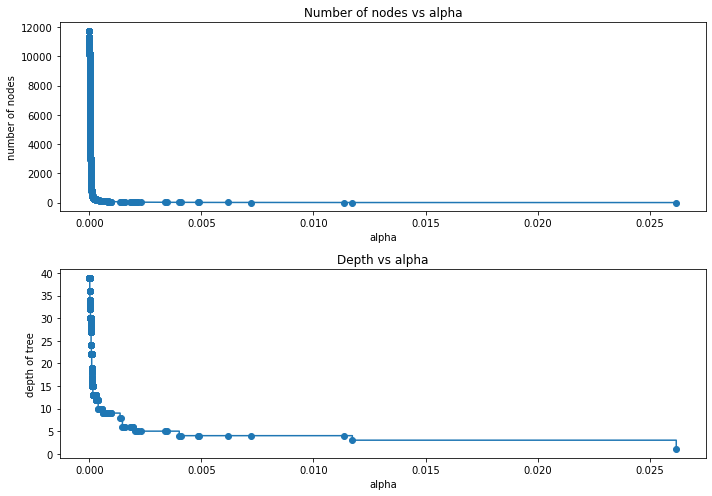

```python
clfs = clfs[:-1]
ccp_alphas = ccp_alphas[:-1]

node_counts = [clf.tree_.node_count for clf in clfs]
depth = [clf.tree_.max_depth for clf in clfs]
fig, ax = plt.subplots(2, 1, figsize=(10, 7))
ax[0].plot(ccp_alphas, node_counts, marker="o", drawstyle="steps-post")
ax[0].set_xlabel("alpha")
ax[0].set_ylabel("number of nodes")
ax[0].set_title("Number of nodes vs alpha")
ax[1].plot(ccp_alphas, depth, marker="o", drawstyle="steps-post")
ax[1].set_xlabel("alpha")
ax[1].set_ylabel("depth of tree")
ax[1].set_title("Depth vs alpha")
fig.tight_layout()
```

### Recall vs alpha for training and testing sets

```python
recall_train = []
for clf in clfs:
    pred_train = clf.predict(X_train)
    values_train = recall_score(y_train, pred_train)
    recall_train.append(values_train)
```

```python
recall_test = []
for clf in clfs:
    pred_test = clf.predict(X_test)
    values_test = recall_score(y_test, pred_test)
    recall_test.append(values_test)
```

```python
# creating the model where we get highest train and test recall
index_best_model = np.argmax(recall_test)
best_model = clfs[index_best_model]
print(best_model)
```

```
DecisionTreeClassifier(ccp_alpha=0.026189654154596814,
                       class_weight={0: 0.62, 1: 0.38}, random_state=1)
```

```python
decision_tree_postpruned_perf_train = model_performance_classification_sklearn(
    best_model, X_train, y_train
)
decision_tree_postpruned_perf_train
```

|  | Accuracy | Recall | Precision | F1 |
| --- | --- | --- | --- | --- |
| 0 | 0.743977 | 0.912708 | 0.737303 | 0.815682 |

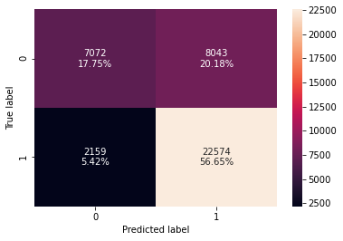

```python
confusion_matrix_sklearn(best_model, X_train, y_train)
```

```python
decision_tree_postpruned_perf_test = model_performance_classification_sklearn(
    best_model, X_test, y_test
)
decision_tree_postpruned_perf_test
```

|  | Accuracy | Recall | Precision | F1 |
| --- | --- | --- | --- | --- |
| 0 | 0.74798 | 0.910474 | 0.743081 | 0.818305 |

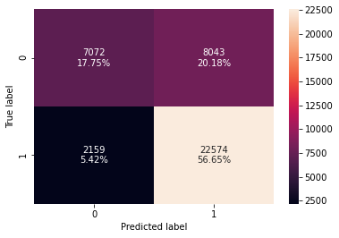

```python
confusion_matrix_sklearn(best_model, X_train, y_train)
```

### Visualizing the Decision Tree

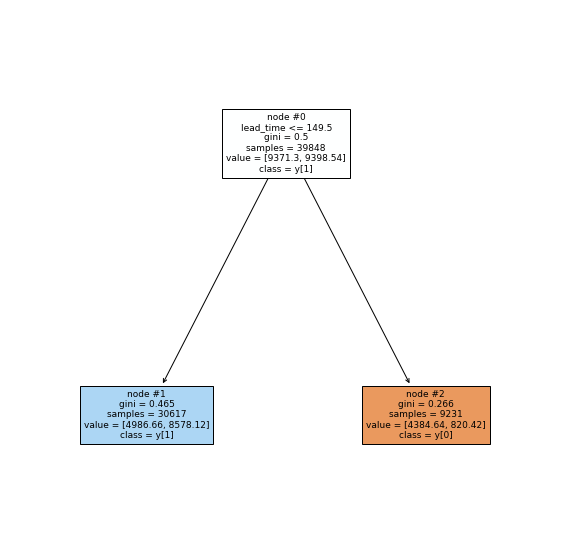

```python
plt.figure(figsize=(10, 10))

out = tree.plot_tree(
    best_model,
    feature_names=feature_names,
    filled=True,
    fontsize=9,
    node_ids=True,
    class_names=True,
)
for o in out:
    arrow = o.arrow_patch
    if arrow is not None:
        arrow.set_edgecolor("black")
        arrow.set_linewidth(1)
plt.show()
plt.show()
```

```python
# Text report showing the rules of a decision tree -

print(tree.export_text(best_model, feature_names=feature_names, show_weights=True))
```

```
|--- lead_time <= 149.50
|   |--- weights: [4986.66, 8578.12] class: 1
|--- lead_time >  149.50
|   |--- weights: [4384.64, 820.42] class: 0
```

```python
# importance of features in the tree building ( The importance of a feature is computed as the
# (normalized) total reduction of the 'criterion' brought by that feature. It is also known as the Gini importance )

print(
    pd.DataFrame(
        best_model.feature_importances_, columns=["Imp"], index=X_train.columns
    ).sort_values(by="Imp", ascending=False)
)
```

```
                                      Imp
lead_time                             1.0
no_of_adults                          0.0
type_of_meal_plan_Meal Plan 2         0.0
market_segment_type_Offline           0.0
market_segment_type_Corporate         0.0
market_segment_type_Complementary     0.0
room_type_reserved_Room_Type 7        0.0
room_type_reserved_Room_Type 6        0.0
room_type_reserved_Room_Type 5        0.0
room_type_reserved_Room_Type 4        0.0
room_type_reserved_Room_Type 3        0.0
room_type_reserved_Room_Type 2        0.0
type_of_meal_plan_Not Selected        0.0
type_of_meal_plan_Meal Plan 3         0.0
no_of_special_requests                0.0
no_of_children                        0.0
avg_price_per_room                    0.0
no_of_previous_bookings_not_canceled  0.0
no_of_previous_cancellations          0.0
repeated_guest                        0.0
arrival_date                          0.0
arrival_month                         0.0
arrival_year                          0.0
required_car_parking_space            0.0
no_of_week_nights                     0.0
no_of_weekend_nights                  0.0
market_segment_type_Online            0.0
```

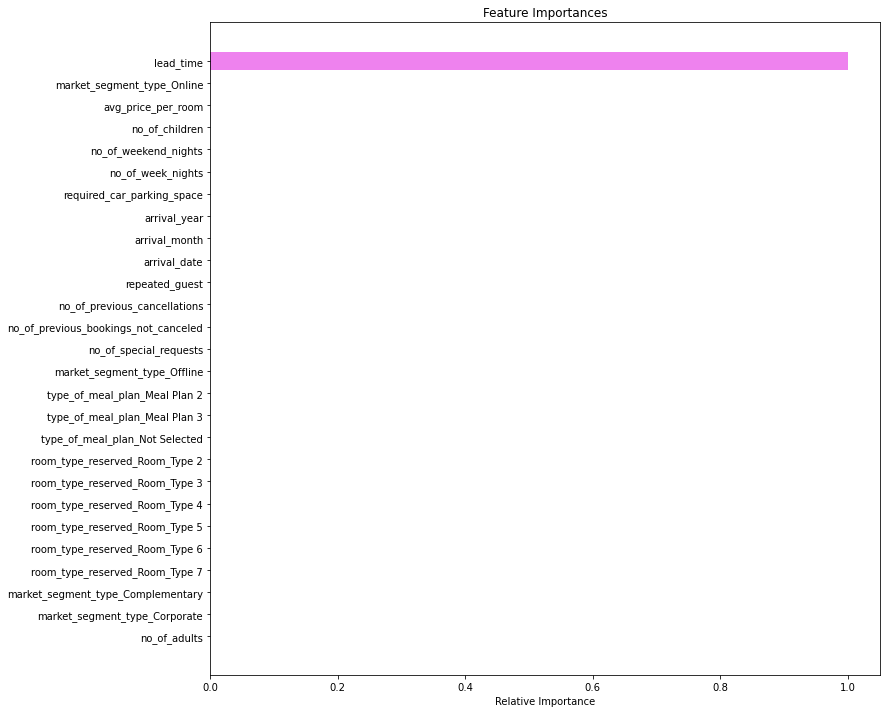

```python
importances = best_model.feature_importances_
indices = np.argsort(importances)

plt.figure(figsize=(12, 12))
plt.title("Feature Importances")
plt.barh(range(len(indices)), importances[indices], color="violet", align="center")
plt.yticks(range(len(indices)), [feature_names[i] for i in indices])
plt.xlabel("Relative Importance")
plt.show()
```

- Lead time remains the most important feature with post-pruning too.

### Comparing all the decision tree models

```python
# training performance comparison

models_train_comp_df = pd.concat(
    [
        decision_tree_perf_train.T,
        decision_tree_tune_perf_train.T,
        decision_tree_postpruned_perf_train.T,
    ],
    axis=1,
)
models_train_comp_df.columns = [
    "Decision Tree sklearn",
    "Decision Tree (Pre-Pruning)",
    "Decision Tree (Post-Pruning)",
]
print("Training performance comparison:")
models_train_comp_df
```

```
Training performance comparison:
```

|  | Decision Tree sklearn | Decision Tree (Pre-Pruning) | Decision Tree (Post-Pruning) |
| --- | --- | --- | --- |
| Accuracy | 0.994203 | 0.994128 | 0.743977 |
| Recall | 0.993571 | 0.993571 | 0.912708 |
| Precision | 0.997079 | 0.996957 | 0.737303 |
| F1 | 0.995322 | 0.995261 | 0.815682 |

```python
# test performance comparison

models_train_comp_df = pd.concat(
    [
        decision_tree_perf_test.T,
        decision_tree_tune_perf_test.T,
        decision_tree_postpruned_perf_test.T,
    ],
    axis=1,
)
models_train_comp_df.columns = [
    "Decision Tree sklearn",
    "Decision Tree (Pre-Pruning)",
    "Decision Tree (Post-Pruning)",
]
print("Test set performance comparison:")
models_train_comp_df
```

```
Test set performance comparison:
```

|  | Decision Tree sklearn | Decision Tree (Pre-Pruning) | Decision Tree (Post-Pruning) |
| --- | --- | --- | --- |
| Accuracy | 0.849690 | 0.850861 | 0.747980 |
| Recall | 0.875716 | 0.877595 | 0.910474 |
| Precision | 0.882264 | 0.882486 | 0.743081 |
| F1 | 0.878978 | 0.880034 | 0.818305 |

- Decision tree with post-pruning is giving the highest recall on the test set

### Business Insights

- If there is a lead time of 151 days or more,there is high likely that the booking will be cancelled by the guest
- If the lead time is 151 days or more and there are special requests in the booking then there is a good chance that the booking will be not cancelled
- If the lead time is 151 days or more and the booking is made through the online portal then there is a good chance that the booking will be not cancelled
- If the average price per room is less than 204 euros then there is a high chance of non cancellation
- June month bookings that are booked that are coming through the above decision steps have a high chance of non cancellation